# Data Science for Business - Final Project

Andrea Barabas (153651)

6 March 2016

# Data Source and Description

In the framework of this project, I chose a publicly available dataset from [Kaggle](https://www.kaggle.com/c/airbnb-recruiting-new-user-bookings/data). I did not follow the rules of the competition, instead I focused on an exploratory data analysis, feature engineering and modelling based on the material the Data Science lectures covered.

New users on Airbnb can book a place to stay in 34,000+ cities across 190+ countries. By accurately predicting where a new user will book their first travel experience, Airbnb can share more personalized content with their community, decrease the average time to first booking, and better forecast demand.

*Predictor variables: + id: user id + date_account_created: the date of account creation + timestamp_first_active: timestamp of the first activity + date_first_booking: date of first booking + gender + age + signup_method + signup_flow: the page a user came to signup up from + language: international language preference + affiliate_channel: what kind of paid marketing + affiliate_provider: where the marketing is e.g. google, craigslist, other + first_affiliate_tracked: whats the first marketing the user interacted with before the signing up + signup_app + first_device_type + first_browser + country_destination: this is the target variable you are to predict

# Exploratory data analysis (EDA)

```r
na_count <-sapply(air_train, function(y) sum(length(which(is.na(y)))))
na_count <- data.frame(na_count)
na_count
air_train$timestamp_first_active <- as.Date(strptime(air_train$timestamp_first_active,format="%Y%m%d%H%M%S"))
air_train$date_account_created <- as.Date(air_train$date_account_created)
```

[output not shown]

# Predictor: Age

```r
length(which(air_train$age > 100))
```

```
## [1] 2345
```

```r
length(which(air_train$age < 18))
```

```
## [1] 158
```

```r
summary(air_train$age)
```

```
##    Min. 1st Qu.  Median    Mean 3rd Qu.    Max.    NA's
##    1.00   28.00   34.00   49.67   43.00 2014.00   87990
```

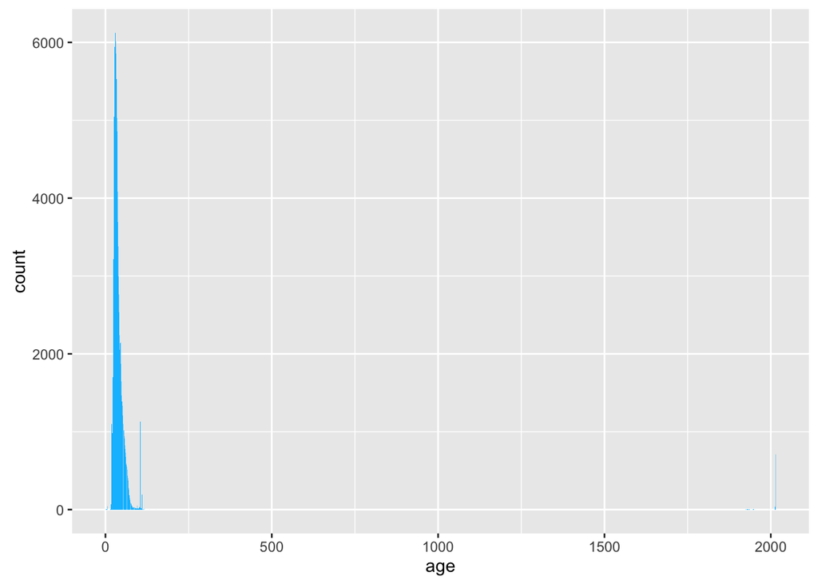

```r
ggplot(air_train) + geom_bar(aes(x = age),fill="deepskyblue")
```

## Heatmap for age (between 18 and 100) and date of accounts created

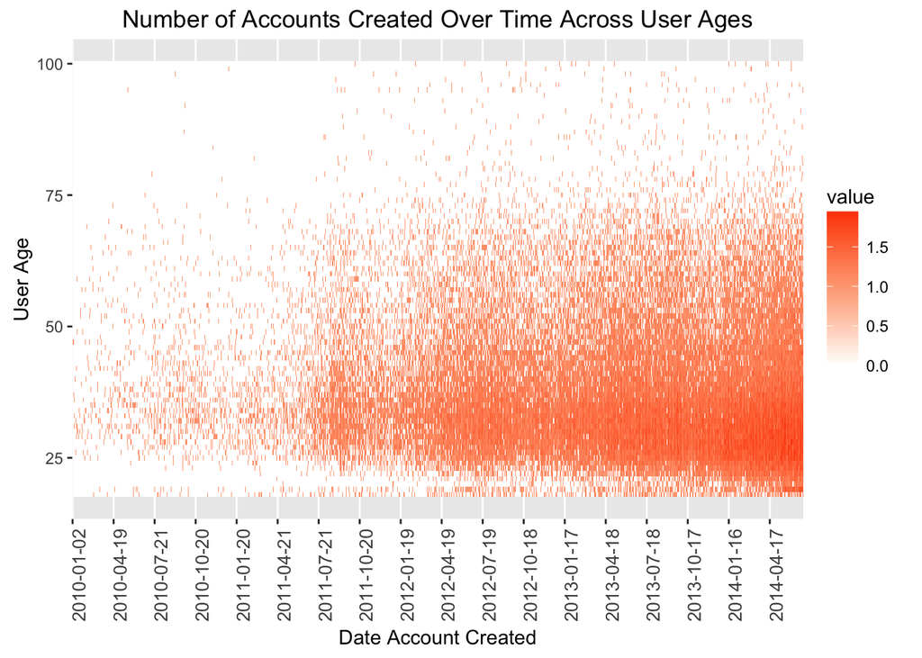

The heatmap shows that that account creation of the site has gradually increased over the years but account creation has largely been dominated by the 25-50 year bucket ever since. Due to the large number of missing values as well as the thousands of values above 100 years, I decided not to use the age column.

# Predictor: signup_method

```r
air_train<- data.table(air_train)
air_train[,.N, by=signup_method] #basic, facebook, google
```

```
##    signup_method      N
## 1:      facebook  60008
## 2:         basic 152897
## 3:        google    546
```

```r
air_train %>% group_by(country_destination, `signup_method`) %>%
  summarize(n = n()) %>% as.data.frame
```

```
##    country_destination signup_method     n
## 1                  NDF      facebook 36252
## 2                   US         basic 45430
## 3                other      facebook  2652
## 4                  NDF         basic 87846
## 5                   FR         basic  3767
## 6                   CA         basic  1105
## 7                   GB         basic  1727
## 8                   ES         basic  1601
## 9                other         basic  7430
## 10                  US      facebook 16867
## 11                  IT         basic  2147
## 12                  CA      facebook   322
## 13                  IT      facebook   686
## 14                  PT         basic   154
```

[output cut: 19 more lines]

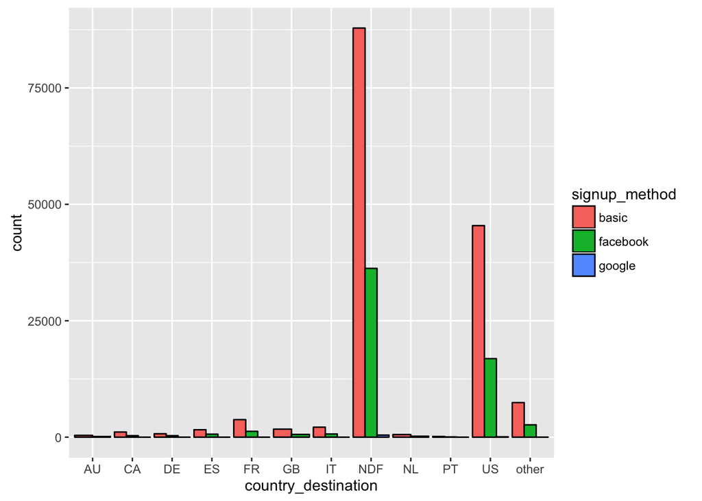

## By taking out the NDF country destination:

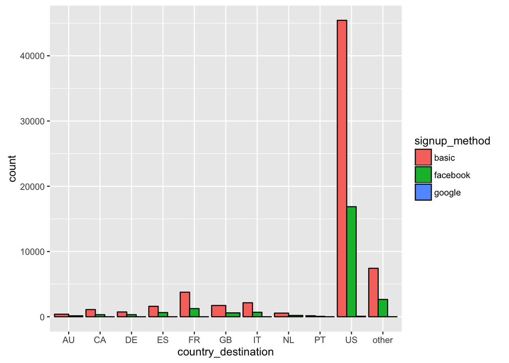

# Predictor: gender

```
##       gender     N
## 1:    FEMALE 31993
## 2: -unknown- 29018
## 3:      MALE 27721
## 4:     OTHER   176
```

```
##    country_destination    gender     n
## 1                   US    FEMALE 22694
## 2                other    FEMALE  3160
## 3                   US -unknown- 20109
## 4                   FR -unknown-  1713
## 5                   CA    FEMALE   455
## 6                   FR    FEMALE  1962
## 7                   US      MALE 19457
## 8                   GB -unknown-   758
## 9                   ES -unknown-   715
## 10                  CA -unknown-   491
## 11                  CA      MALE   477
## 12               other -unknown-  3469
## 13                  IT    FEMALE  1091
## 14                  ES     OTHER     4
```

[output cut: 30 more lines]

By taking out the “unknown” and “other” variables, the graph looks the following:

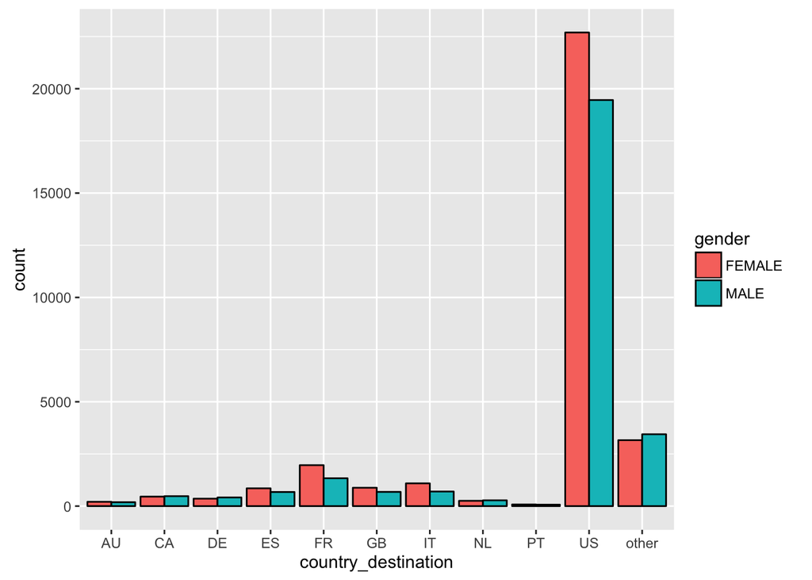

# Predictor: signup_app

[output not shown]

```
##    country_destination signup_app     n
## 1                   US        Web 37515
## 2                other        Web  5916
## 3                   CA        Web   854
## 4                   FR        Web  3086
## 5                   IT        Web  1668
## 6                   GB        Web  1462
## 7                   PT        Web   137
## 8                   NL        Web   493
## 9                   ES        Web  1410
## 10                  DE        Web   724
## 11                  AU        Web   362
## 12                  GB        iOS    72
## 13                  US        iOS  2908
## 14                  US      Moweb  1108
```

[output cut: 30 more lines]

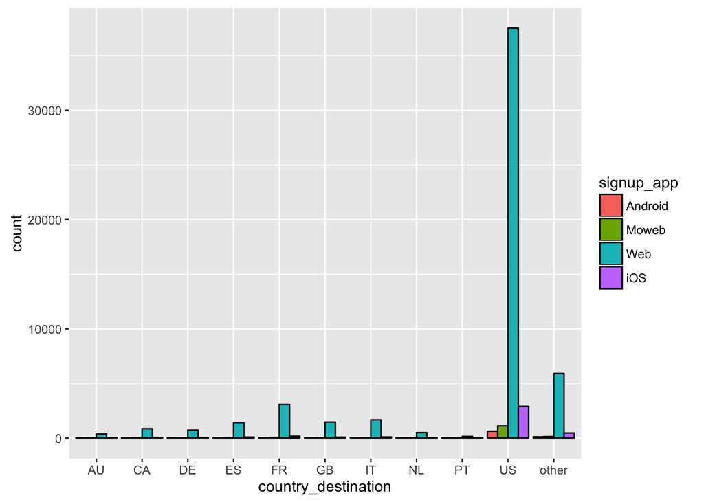

# Predictor: language

```
##     language     N
##  1:       en 58131
##  2:       fr   283
##  3:       es   201
##  4:       zh   364
##  5:       ko   142
##  6:       ja    59
##  7:       it    80
##  8:       pt    52
##  9:       ru    86
## 10:       nl    18
## 11:       de   181
## 12:       sv    37
## 13:       pl    11
## 14:       hu     4
## 15:       da    15
## 16:       fi     6
## 17:       tr    17
## 18:       no    11
## 19:       cs     5
## 20:       th     2
## 21:       ca     2
## 22:       is     2
## 23:       el     5
##     language     N
```

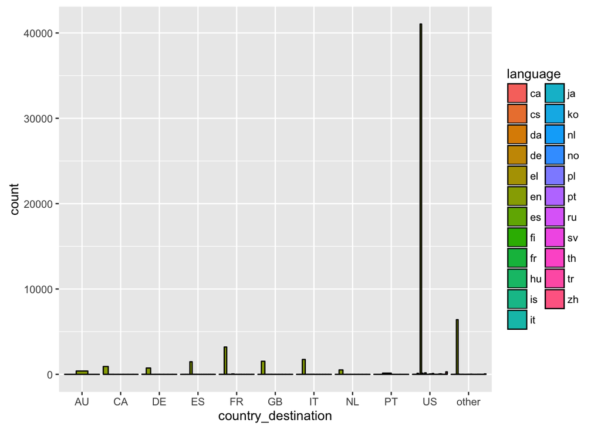

# Predictor: affiliate_provider

```
##      affiliate_provider     N
##  1:              direct 39554
##  2:          craigslist  1015
##  3:              google 13632
##  4:               other  3692
##  5:            facebook   597
##  6:                vast   168
##  7:                bing   538
##  8: facebook-open-graph   120
##  9:     email-marketing    24
## 10:              meetup    33
## 11:               yahoo   108
## 12:           padmapper   184
## 13:                 gsp    28
## 14:               baidu     8
## 15:               naver     9
## 16:              yandex     4
```

```
##     country_destination  affiliate_provider     n
## 1                    US              direct 27857
## 2                 other              direct  4390
## 3                    US          craigslist   865
## 4                    CA              direct   617
## 5                    FR              direct  2187
## 6                    FR          craigslist    29
## 7                    IT              direct  1185
## 8                    US              google  9291
## 9                    CA               other    43
## 10                   GB              google   382
## 11                   US               other  2885
## 12                   FR              google   869
## 13                   US            facebook   384
## 14                   PT          craigslist     2
```

[output cut: 108 more lines]

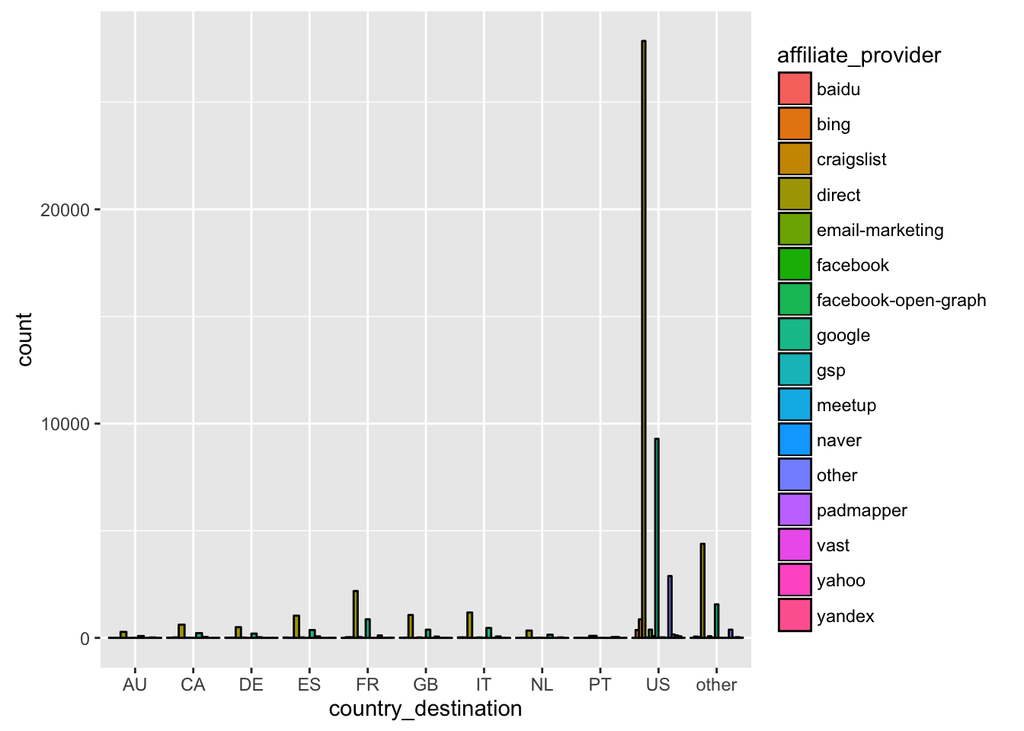

## Predictors: date first booking, timestamp first active and date account created

I created separate columns for the time difference between the first visit to the page and the actual account creation to assess its potential predictive power.

# Target variable: Country_destination

(“NDF” value has already been taken out)

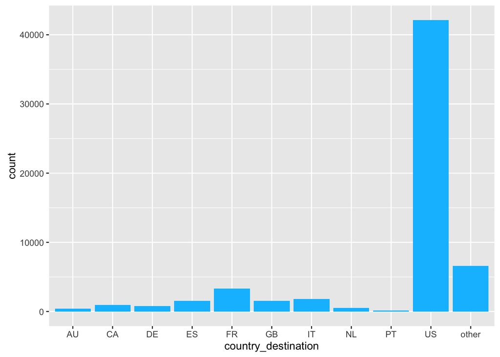

# Modelling - Training set

[output not shown]

## Random Forest

```r
summary(airbnb.rf)
```

```
## Model Details:
## ==============
##
## H2OMultinomialModel: drf
## Model Key:  DRF_model_R_1457260193397_4
## Model Summary:
##   number_of_trees model_size_in_bytes min_depth max_depth mean_depth
## 1             550             2912129        13        20   19.87818
##   min_leaves max_leaves mean_leaves
## 1         59       1778   448.51636
##
## H2OMultinomialMetrics: drf
## ** Reported on training data. **
## Description: Metrics reported on Out-Of-Bag training samples
##
## Training Set Metrics:
## =====================
## Metrics reported on Out-Of-Bag training samples
##
## Extract training frame with `h2o.getFrame("d_train")`
## MSE: (Extract with `h2o.mse`) 0.3126786
## R^2: (Extract with `h2o.r2`) 0.9336427
## Logloss: (Extract with `h2o.logloss`) 1.653714
## Confusion Matrix: Extract with `h2o.confusionMatrix(<model>,train = TRUE)`)
## =========================================================================
## Confusion Matrix: vertical: actual; across: predicted
##        AU CA DE ES FR GB IT NL PT    US other  Error             Rate
## AU      0  0  0  0  0  0  0  0  0   205     2 1.0000 =      207 / 207
## CA      0  1  0  0  0  0  0  0  0   477     4 0.9979 =      481 / 482
## DE      0  0  2  0  1  0  0  0  0   379     1 0.9948 =      381 / 383
## ES      0  0  0  0  0  0  0  0  0   769     1 1.0000 =      770 / 770
## FR      0  0  0  0  5  0  0  0  0  1637     4 0.9970 =  1,641 / 1,646
## GB      0  0  0  0  0  0  0  0  0   804     2 1.0000 =      806 / 806
## IT      0  0  0  0  0  0  0  0  0   866     4 1.0000 =      870 / 870
## NL      0  0  0  0  0  0  0  0  0   258     0 1.0000 =      258 / 258
## PT      0  0  0  0  0  0  0  0  0    80     0 1.0000 =        80 / 80
## US      0  7  4  8 16  6  8  1  1 20845    88 0.0066 =   139 / 20,984
## other   0  0  1  0  3  2  0  0  0  3334    18 0.9946 =  3,340 / 3,358
## Totals  0  8  7  8 25  8  8  1  1 29654   124 0.3007 = 8,973 / 29,844
##
```

[output cut: 175 more lines]

```
## 9            signup_method         2897.916504          0.134135
## 10                  gender         2402.770264          0.111216
## 11              signup_app         1568.080933          0.072581
##    percentage
## 1    0.285206
## 2    0.122636
## 3    0.113110
## 4    0.097882
## 5    0.084348
## 6    0.080404
## 7    0.072381
## 8    0.053357
## 9    0.038256
## 10   0.031720
## 11   0.020701
```

## GBM

```r
summary(airbnb.gbm)
```

```
## Model Details:
## ==============
##
## H2OMultinomialModel: gbm
## Model Key:  airbnb.gbm
## Model Summary:
##   number_of_trees model_size_in_bytes min_depth max_depth mean_depth
## 1             550              139838         5         5    5.00000
##   min_leaves max_leaves mean_leaves
## 1          7         32    16.43091
##
## H2OMultinomialMetrics: gbm
## ** Reported on training data. **
##
## Training Set Metrics:
## =====================
##
## Extract training frame with `h2o.getFrame("d_train")`
## MSE: (Extract with `h2o.mse`) 0.3089765
## R^2: (Extract with `h2o.r2`) 0.9344284
## Logloss: (Extract with `h2o.logloss`) 1.06646
## Confusion Matrix: Extract with `h2o.confusionMatrix(<model>,train = TRUE)`)
## =========================================================================
## Confusion Matrix: vertical: actual; across: predicted
##        AU CA DE ES FR GB IT NL PT    US other  Error             Rate
## AU      0  0  0  0  0  0  0  0  0   207     0 1.0000 =      207 / 207
## CA      0  3  0  0  0  0  0  0  0   479     0 0.9938 =      479 / 482
## DE      0  0 11  0  0  0  0  0  0   372     0 0.9713 =      372 / 383
## ES      0  0  0  3  0  0  0  0  0   767     0 0.9961 =      767 / 770
## FR      0  0  0  1 16  0  0  0  0  1628     1 0.9903 =  1,630 / 1,646
## GB      0  0  0  0  0  2  0  0  0   804     0 0.9975 =      804 / 806
## IT      0  0  0  0  0  0  8  0  0   861     1 0.9908 =      862 / 870
## NL      0  0  0  0  0  0  0  3  0   255     0 0.9884 =      255 / 258
## PT      0  0  0  0  0  0  0  0  3    77     0 0.9625 =        77 / 80
## US      0  0  0  0  2  0  0  0  0 20980     2 0.0002 =     4 / 20,984
## other   0  0  0  0  0  0  0  0  0  3312    46 0.9863 =  3,312 / 3,358
## Totals  0  3 11  4 18  2  8  3  3 29742    50 0.2938 = 8,769 / 29,844
##
## Hit Ratio Table: Extract with `h2o.hit_ratio_table(<model>,train = TRUE)`
## =======================================================================
```

[output cut: 190 more lines]

```
##    percentage
## 1    0.163605
## 2    0.123547
## 3    0.114245
## 4    0.102958
## 5    0.100602
## 6    0.094755
## 7    0.081209
## 8    0.058143
## 9    0.048704
## 10   0.037147
## 11   0.033977
## 12   0.014099
## 13   0.013881
## 14   0.013127
```

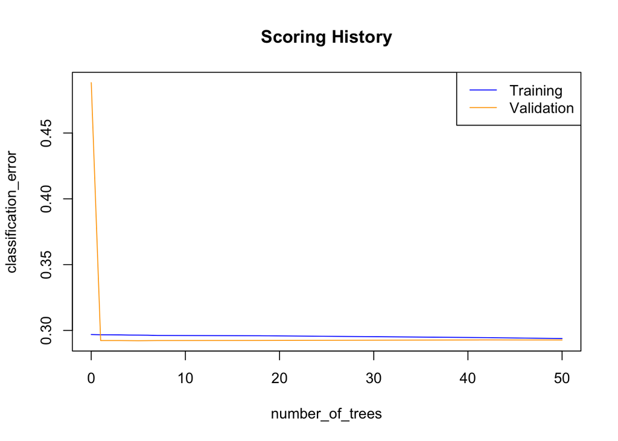

```r
plot(airbnb.gbm)
```

## GBM with cross validation

```r
summary(airbnb1.gbm)
```

```
## Model Details:
## ==============
##
## H2OMultinomialModel: gbm
## Model Key:  GBM_model_R_1457260193397_5
## Model Summary:
##   number_of_trees model_size_in_bytes min_depth max_depth mean_depth
## 1            5500            25229375        15        15   15.00000
##   min_leaves max_leaves mean_leaves
## 1         77       1004   388.74620
##
## H2OMultinomialMetrics: gbm
## ** Reported on training data. **
##
## Training Set Metrics:
## =====================
##
## Extract training frame with `h2o.getFrame("d_train")`
## MSE: (Extract with `h2o.mse`) 0.1969984
## R^2: (Extract with `h2o.r2`) 0.9581926
## Logloss: (Extract with `h2o.logloss`) 0.6099046
## Confusion Matrix: Extract with `h2o.confusionMatrix(<model>,train = TRUE)`)
## =========================================================================
## Confusion Matrix: vertical: actual; across: predicted
##         AU  CA  DE  ES  FR  GB  IT  NL PT    US other  Error
## AU     102   0   0   0   0   0   0   0  0   105     0 0.5072
## CA       0 184   0   0   0   0   0   0  0   298     0 0.6183
## DE       0   0 149   0   0   0   0   0  0   234     0 0.6110
## ES       0   0   0 195   0   0   0   0  0   574     1 0.7468
## FR       0   0   0   0 299   0   0   0  0  1346     1 0.8183
## GB       0   0   0   0   0 163   0   0  0   643     0 0.7978
## IT       0   0   0   0   1   0 194   0  0   675     0 0.7770
## NL       0   0   0   0   0   0   0 110  0   148     0 0.5736
## PT       0   0   0   0   0   0   0   0 48    32     0 0.4000
## US       0   1   0   0   0   0   0   0  0 20982     1 0.0001
## other    0   0   0   0   0   0   0   0  0  2590   768 0.7713
## Totals 102 185 149 195 300 163 194 110 48 27627   771 0.2228
##                    Rate
## AU     =      105 / 207
## CA     =      298 / 482
```

[output cut: 128 more lines]

```
##    percentage
## 1    0.150648
## 2    0.133342
## 3    0.131068
## 4    0.123380
## 5    0.113543
## 6    0.071942
## 7    0.066028
## 8    0.063357
## 9    0.056581
## 10   0.025018
## 11   0.021461
## 12   0.020022
## 13   0.018143
## 14   0.005467
```

# Test set

```r
model_perf_rf
```

```
## H2OMultinomialMetrics: drf
##
## Test Set Metrics:
## =====================
##
## MSE: (Extract with `h2o.mse`) 0.3042262
## R^2: (Extract with `h2o.r2`) 0.9339523
## Logloss: (Extract with `h2o.logloss`) 1.332893
## Confusion Matrix: Extract with `h2o.confusionMatrix(<model>, <data>)`)
## =========================================================================
## Confusion Matrix: vertical: actual; across: predicted
##        AU CA DE ES FR GB IT NL PT    US other  Error             Rate
## AU      0  0  0  0  0  0  0  0  0   100     0 1.0000 =      100 / 100
## CA      0  0  0  0  0  0  1  0  0   212     0 1.0000 =      213 / 213
## DE      0  0  0  0  0  0  0  0  0   193     0 1.0000 =      193 / 193
## ES      0  1  1  0  0  0  0  0  0   387     1 1.0000 =      390 / 390
## FR      0  0  1  1  3  0  0  0  0   833     2 0.9964 =      837 / 840
## GB      0  0  0  0  0  0  0  0  0   371     1 1.0000 =      372 / 372
## IT      0  0  0  0  0  0  0  0  0   453     2 1.0000 =      455 / 455
## NL      0  0  0  0  0  0  0  0  0   129     1 1.0000 =      130 / 130
## PT      0  0  0  0  0  0  0  0  0    34     0 1.0000 =        34 / 34
## US      2  2  0  1  4  1  0  0  0 10558    19 0.0027 =    29 / 10,587
## other   0  0  0  0  0  0  0  0  0  1605     3 0.9981 =  1,605 / 1,608
## Totals  2  3  2  2  7  1  1  0  0 14875    29 0.2921 = 4,358 / 14,922
##
## Hit Ratio Table: Extract with `h2o.hit_ratio_table(<model>, <data>)`
## =======================================================================
## Top-10 Hit Ratios:
##     k hit_ratio
## 1   1  0.707948
## 2   2  0.810548
## 3   3  0.860810
## 4   4  0.894317
## 5   5  0.921257
## 6   6  0.946991
## 7   7  0.964884
## 8   8  0.977483
## 9   9  0.988004
## 10 10  0.993768
```

```r
model_perf_gbm
```

```
## H2OMultinomialMetrics: gbm
##
## Test Set Metrics:
## =====================
##
## MSE: (Extract with `h2o.mse`) 0.3169558
## R^2: (Extract with `h2o.r2`) 0.9311886
## Logloss: (Extract with `h2o.logloss`) 1.1372
## Confusion Matrix: Extract with `h2o.confusionMatrix(<model>, <data>)`)
## =========================================================================
## Confusion Matrix: vertical: actual; across: predicted
##        AU CA DE ES FR GB IT NL PT    US other  Error             Rate
## AU      0  0  0  0  0  0  0  0  0   100     0 1.0000 =      100 / 100
## CA      0  0  0  0  0  0  0  0  0   213     0 1.0000 =      213 / 213
## DE      0  0  0  0  0  0  0  0  0   192     1 1.0000 =      193 / 193
## ES      0  0  1  0  0  0  0  0  0   389     0 1.0000 =      390 / 390
## FR      0  0  0  0  1  0  0  0  0   838     1 0.9988 =      839 / 840
## GB      0  0  0  0  0  0  0  0  0   372     0 1.0000 =      372 / 372
## IT      0  0  0  0  0  0  0  0  0   455     0 1.0000 =      455 / 455
## NL      0  0  0  0  0  0  0  0  0   130     0 1.0000 =      130 / 130
## PT      0  0  0  0  0  0  0  0  0    34     0 1.0000 =        34 / 34
## US      0  0  1  0  2  0  0  0  0 10579     5 0.0008 =     8 / 10,587
## other   0  0  1  0  0  0  0  0  0  1606     1 0.9994 =  1,607 / 1,608
## Totals  0  0  3  0  3  0  0  0  0 14908     8 0.2909 = 4,341 / 14,922
##
## Hit Ratio Table: Extract with `h2o.hit_ratio_table(<model>, <data>)`
## =======================================================================
## Top-10 Hit Ratios:
##     k hit_ratio
## 1   1  0.709087
## 2   2  0.817049
## 3   3  0.870929
## 4   4  0.902091
## 5   5  0.927423
## 6   6  0.952955
## 7   7  0.969843
## 8   8  0.981906
## 9   9  0.991221
## 10 10  0.997587
```

```r
model_perf_gbm1
```

```
## H2OMultinomialMetrics: gbm
##
## Test Set Metrics:
## =====================
##
## MSE: (Extract with `h2o.mse`) 0.3139239
## R^2: (Extract with `h2o.r2`) 0.9318469
## Logloss: (Extract with `h2o.logloss`) 1.182941
## Confusion Matrix: Extract with `h2o.confusionMatrix(<model>, <data>)`)
## =========================================================================
## Confusion Matrix: vertical: actual; across: predicted
##        AU CA DE ES FR GB IT NL PT    US other  Error             Rate
## AU      0  0  0  0  0  0  0  0  0   100     0 1.0000 =      100 / 100
## CA      0  1  0  0  0  0  1  0  0   210     1 0.9953 =      212 / 213
## DE      0  0  0  0  0  0  0  0  0   192     1 1.0000 =      193 / 193
## ES      0  0  2  0  1  0  0  0  0   386     1 1.0000 =      390 / 390
## FR      0  0  0  1  3  0  0  0  0   830     6 0.9964 =      837 / 840
## GB      0  0  0  1  0  0  1  0  0   370     0 1.0000 =      372 / 372
## IT      0  0  0  0  1  0  0  0  0   450     4 1.0000 =      455 / 455
## NL      0  0  0  0  1  0  0  0  0   128     1 1.0000 =      130 / 130
## PT      0  0  0  0  0  0  0  0  0    32     2 1.0000 =        34 / 34
## US      1  1  0  4  9  2  3  0  0 10506    61 0.0077 =    81 / 10,587
## other   0  0  1  0  1  0  1  0  0  1598     7 0.9956 =  1,601 / 1,608
## Totals  1  2  3  6 16  2  6  0  0 14802    84 0.2952 = 4,405 / 14,922
##
## Hit Ratio Table: Extract with `h2o.hit_ratio_table(<model>, <data>)`
## =======================================================================
## Top-10 Hit Ratios:
##     k hit_ratio
## 1   1  0.704798
## 2   2  0.810816
## 3   3  0.863155
## 4   4  0.897333
## 5   5  0.924005
## 6   6  0.948532
## 7   7  0.966962
## 8   8  0.980566
## 9   9  0.989814
## 10 10  0.997319
```

```r
model_perf_nn
```

```
## H2OMultinomialMetrics: deeplearning
##
## Test Set Metrics:
## =====================
##
## MSE: (Extract with `h2o.mse`) 0.3540556
## R^2: (Extract with `h2o.r2`) 0.9231343
## Logloss: (Extract with `h2o.logloss`) 1.172414
## Confusion Matrix: Extract with `h2o.confusionMatrix(<model>, <data>)`)
## =========================================================================
## Confusion Matrix: vertical: actual; across: predicted
##        AU CA DE ES FR GB IT NL PT    US other  Error             Rate
## AU      0  0  0  0  0  0  0  0  0   100     0 1.0000 =      100 / 100
## CA      0  0  0  0  0  0  0  0  0   213     0 1.0000 =      213 / 213
## DE      0  0  0  0  0  0  0  0  0   193     0 1.0000 =      193 / 193
## ES      0  0  0  0  0  0  0  0  0   389     1 1.0000 =      390 / 390
## FR      0  0  0  0  1  0  0  0  0   839     0 0.9988 =      839 / 840
## GB      0  0  0  0  0  0  0  0  0   371     1 1.0000 =      372 / 372
## IT      0  0  0  0  0  0  0  0  0   455     0 1.0000 =      455 / 455
## NL      0  0  0  0  0  0  0  0  0   130     0 1.0000 =      130 / 130
## PT      0  0  0  0  0  0  0  0  0    33     1 1.0000 =        34 / 34
## US      0  0  0  0  4  0  0  0  0 10572    11 0.0014 =    15 / 10,587
## other   0  0  0  0  0  0  0  0  0  1607     1 0.9994 =  1,607 / 1,608
## Totals  0  0  0  0  5  0  0  0  0 14902    15 0.2914 = 4,348 / 14,922
##
## Hit Ratio Table: Extract with `h2o.hit_ratio_table(<model>, <data>)`
## =======================================================================
## Top-10 Hit Ratios:
##     k hit_ratio
## 1   1  0.708618
## 2   2  0.813765
## 3   3  0.868449
## 4   4  0.903431
## 5   5  0.928897
## 6   6  0.954564
## 7   7  0.968771
## 8   8  0.980432
## 9   9  0.989210
## 10 10  0.997587
```